# Assignment 12: Predictive Modeling - Part 3

*How to do it?*:

- Open the Rmarkdown file of this assignment (link) in Rstudio.
- Right under each **question**, insert a code chunk (you can use the hotkey `Ctrl + Alt + I` to add a code chunk) and code the solution for the question.
- `Knit` the rmarkdown file (hotkey: `Ctrl + Alt + K`) to export an html.
- Publish the html file to your Githiub Page.

*Submission*: Submit the link on Github of the assignment to Blackboard.

1. Use the `PimaIndiansDiabetes` dataset. Use 15% data for testing. Use cross-validation with of 7 folds to tune random forest `(method='ranger')`. What are the parameters that produce the greatest accuracy? What is the testing accuracy.

```r
library(mlbench)
library(tidyverse)
data(PimaIndiansDiabetes)
df <- tibble(PimaIndiansDiabetes)
head(df)
```

```
## # A tibble: 6 × 9
##   pregnant glucose pressure triceps insulin  mass pedigree   age diabetes
##      <dbl>   <dbl>    <dbl>   <dbl>   <dbl> <dbl>    <dbl> <dbl> <fct>
## 1        6     148       72      35       0  33.6    0.627    50 pos
## 2        1      85       66      29       0  26.6    0.351    31 neg
## 3        8     183       64       0       0  23.3    0.672    32 pos
## 4        1      89       66      23      94  28.1    0.167    21 neg
## 5        0     137       40      35     168  43.1    2.29     33 pos
## 6        5     116       74       0       0  25.6    0.201    30 neg
```

```r
df <- df %>% rename(target=diabetes)
```

```r
colSums(is.na(df))
```

```
## pregnant  glucose pressure  triceps  insulin     mass pedigree      age
##        0        0        0        0        0        0        0        0
##   target
##        0
```

```r
library(caret)
splitIndex <- createDataPartition(df$target, p = .75,
                                  list = FALSE)
df_train <- df[ splitIndex,]
df_test <- df[-splitIndex,]
```

```r
trControl = trainControl(method = "cv",
                         number = 7)

tuneGrid = expand.grid(mtry = 2:4,
                       splitrule = c('gini', 'extratrees'),
                       min.node.size = c(1:10))

forest_ranger <- train(target~., data=df_train,
                    method = "ranger",
                    trControl = trControl,
                    tuneGrid = tuneGrid)
```

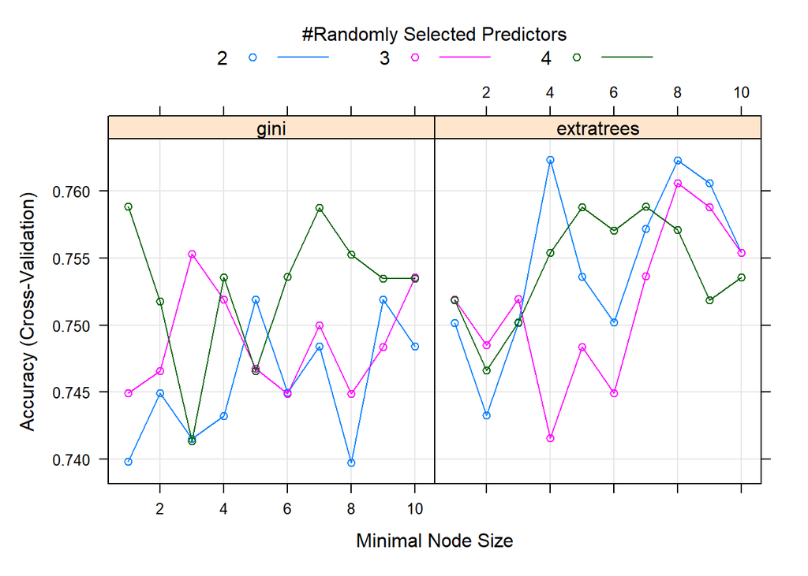

```r
plot(forest_ranger)
```

```r
forest_ranger
```

```
## Random Forest
##
## 576 samples
##   8 predictor
##   2 classes: 'neg', 'pos'
##
## No pre-processing
## Resampling: Cross-Validated (7 fold)
## Summary of sample sizes: 495, 494, 494, 494, 493, 493, ...
## Resampling results across tuning parameters:
##
##   mtry  splitrule   min.node.size  Accuracy   Kappa
##   2     gini         1             0.7398016  0.4090860
##   2     gini         2             0.7449006  0.4248385
##   2     gini         3             0.7415013  0.4159429
```

[output cut: 61 more lines]

```r
pred <- predict(forest_ranger, df_test)
cm <- confusionMatrix(data = pred, reference = df_test$target)
cm$overall[1]
```

```
##  Accuracy
## 0.7604167
```

2. Use the `PimaIndiansDiabetes` dataset. Go to https://topepo.github.io/caret/available-models.html and pick a classification model. Tune the classification model using cross-validation of 7 folds.

```r
data(PimaIndiansDiabetes)
df <- tibble(PimaIndiansDiabetes)
```

```r
df <- df %>% rename(target=diabetes)
```

```r
splitIndex <- createDataPartition(df$target, p = .75,
                                  list = FALSE)
df_train <- df[ splitIndex,]
df_test <- df[-splitIndex,]
```

```r
trControl = trainControl(method = "cv",
                         number = 7)

tuneGrid = expand.grid(predFixed = 2:5,
                       minNode = 10)

forest_Rborist <- train(target~., data=df_train,
                    method = "Rborist",
                    trControl = trControl,
                    tuneGrid = tuneGrid)
```

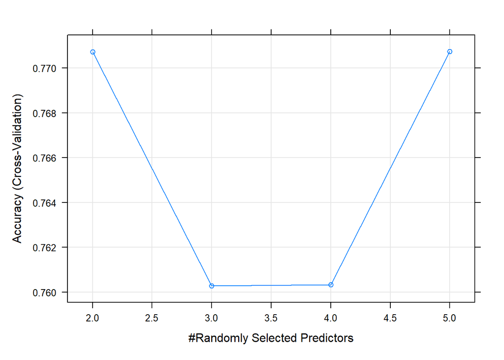

```r
plot(forest_Rborist)
```

```r
forest_Rborist
```

```
## Random Forest
##
## 576 samples
##   8 predictor
##   2 classes: 'neg', 'pos'
##
## No pre-processing
## Resampling: Cross-Validated (7 fold)
## Summary of sample sizes: 494, 494, 494, 493, 494, 493, ...
## Resampling results across tuning parameters:
##
##   predFixed  Accuracy   Kappa
##   2          0.7707275  0.4746679
##   3          0.7602745  0.4550759
##   4          0.7603375  0.4563511
##   5          0.7707485  0.4802977
##
## Tuning parameter 'minNode' was held constant at a value of 10
## Accuracy was used to select the optimal model using the largest value.
## The final values used for the model were predFixed = 5 and minNode = 10.
```

```r
pred <- predict(forest_Rborist, df_test)
cm <- confusionMatrix(data = pred, reference = df_test$target)
cm$overall[1]
```

```
## Accuracy
## 0.796875
```

3. (Model Comparison) Use the `PimaIndiansDiabetes` dataset. Pick two models at [this link](https://topepo.github.io/caret/available-models.html) to compare using 7-fold cross validation method. Evaluate the accuracy of the final model on the test data.

```r
data(PimaIndiansDiabetes)
df <- tibble(PimaIndiansDiabetes)
```

```r
df <- df %>% rename(target=diabetes)
```

```r
splitIndex <- createDataPartition(df$target, p = .75,
                                  list = FALSE)
df_train <- df[ splitIndex,]
df_test <- df[-splitIndex,]
```

```r
trControl = trainControl(method = "cv",
                         number = 2)
```

```r
forest_ordinalRF <- train(target~., data=df_train,
                    method = "ordinalRF",
                                trControl = trControl)
```

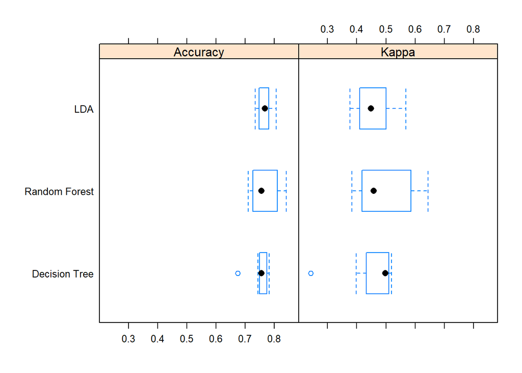

```r
trControl = trainControl(method = "cv",
                         number = 7)

tree <- train(target~., data=df_train,
                                method = "rpart2",
                                trControl = trControl)
forest_ordinalRF <- train(target~., data=df_train,
                    method = "ordinalRF",
                                trControl = trControl)
lda <- train(target~., data=df_train,
                                method = "lda",
                                trControl = trControl)
results <- resamples(list('Decision Tree' = tree,
                          'Random Forest' = forest_ordinalRF,
                          'LDA'= lda))
bwplot(results)
```

```r
pred <- predict(forest_ordinalRF, df_test)
cm <- confusionMatrix(data = pred, reference = df_test$target)
cm$overall[1]
```

```
##  Accuracy
## 0.7864583
```